# Best Flight Days- Initial Data Analysis for Flight Delay Forecasting

## Objective

In this notebook I did some initial data analysis to find patterns in the data and to test some hypothesis. In essence, I was testing to see what variable affect flight delays for further analysis in the other notebook.

## Hypothesis

1. The day of the week affects the delay time. This would make sense because some days are more busy than others. There may be a lot of tourism travel on the weekends, but there is a lot of business travel on Mondays
2. The carrier affects the delay time. This is a bit obvious being that it is an accepted fact that some carriers are more punctial than others, but does the data say the same thing?

## Testing

I used classical statistical methods to test my above hypotheses. Since in both cases I have groups of data that I seperate by one variable I can run ANOVA tests to see if the variance between the groups is sufficient to say that the variable affects the delays- or in more statistical terms, that the groups population means are not the same.

The problem here is that the data is not normal. It is heavily right skewed which makes sense because flights are more likely to be delayed instead of leaving early. This creates a long tail of delayed times. I therefore use non-parametric measures for the tests as they do not assume a normal distribution.

```python
from sqlalchemy import create_engine
import csv
import pandas as pd
import numpy as np
from scipy import stats
import matplotlib
import matplotlib.pyplot as plt
%matplotlib inline
```

### Load Data and Create Database

```python
df = pd.read_csv('/root/seed_assignment/flights1-2.csv')
df = df[['id','DayOfWeek','FlightDate','UniqueCarrier','TailNum','FlightNum','Origin','Dest','CRSDepTime','DepDelay','TaxiOut','WheelsOff','WheelsOn','TaxiIn','CRSArrTime','ArrDelay','Cancelled','CancellationCode','Diverted','AirTime','Distance','CarrierDelay','WeatherDelay','NASDelay','SecurityDelay','LateAircraftDelay']]
df2 = pd.read_csv('/root/seed_assignment/flights3.csv')
df2 = df2[['id','DayOfWeek','FlightDate','UniqueCarrier','TailNum','FlightNum','Origin','Dest','CRSDepTime','DepDelay','TaxiOut','WheelsOff','WheelsOn','TaxiIn','CRSArrTime','ArrDelay','Cancelled','CancellationCode','Diverted','AirTime','Distance','CarrierDelay','WeatherDelay','NASDelay','SecurityDelay','LateAircraftDelay']]
df = df.append(df2)
```

```python
df.head()
```

|  | id | DayOfWeek | FlightDate | UniqueCarrier | TailNum | FlightNum | Origin | Dest | CRSDepTime | DepDelay | ... | Cancelled | CancellationCode | Diverted | AirTime | Distance | CarrierDelay | WeatherDelay | NASDelay | SecurityDelay | LateAircraftDelay |
| --- | --- | --- | --- | --- | --- | --- | --- | --- | --- | --- | --- | --- | --- | --- | --- | --- | --- | --- | --- | --- | --- |
| 0 | 1 | 4 | 1/1/2015 | AA | N787AA | 1 | JFK | LAX | 900 | -5 | ... | 0 | NaN | 0 | 378 | 2475 | NaN | NaN | NaN | NaN | NaN |
| 1 | 2 | 5 | 1/2/2015 | AA | N795AA | 1 | JFK | LAX | 900 | -10 | ... | 0 | NaN | 0 | 357 | 2475 | NaN | NaN | NaN | NaN | NaN |
| 2 | 3 | 6 | 1/3/2015 | AA | N788AA | 1 | JFK | LAX | 900 | -7 | ... | 0 | NaN | 0 | 330 | 2475 | NaN | NaN | NaN | NaN | NaN |
| 3 | 4 | 7 | 1/4/2015 | AA | N791AA | 1 | JFK | LAX | 900 | -7 | ... | 0 | NaN | 0 | 352 | 2475 | NaN | NaN | NaN | NaN | NaN |
| 4 | 5 | 1 | 1/5/2015 | AA | N783AA | 1 | JFK | LAX | 900 | -7 | ... | 0 | NaN | 0 | 338 | 2475 | NaN | NaN | NaN | NaN | NaN |

5 rows × 26 columns

```python
engine = create_engine('sqlite:///flights.db')
#df.to_sql('flights', engine, chunksize=1000)
```

## List of SQL Queries to be used

```python
avg = '''SELECT UniqueCarrier, FlightNum, AVG(DepDelay), COUNT(*)
         FROM flights
         GROUP BY FlightNum, TailNum
         HAVING UniqueCarrier = 'AA' '''


daysAvg = '''SELECT DayofWeek, AVG(DepDelay)
             FROM flights
             GROUP BY DayofWeek'''

qDelays = '''SELECT id, DepDelay
             FROM flights
             WhERE DepDelay <60
             LIMIT 10000'''

delayGT60 = '''SELECT DayofWeek, COUNT(DepDelay), AVG(DepDelay)
             FROM flights
             WhERE DepDelay > 60
             GROUP BY DayOfWeek
             '''

countFlights = '''SELECT DayOfWeek, COUNT(*)
                  FROM flights
                  GROUP BY DayOfWeek'''

qCan= '''Select DayofWeek, SUM(cancelled)
                    FROM flights
                    GROUP BY DayofWeek'''

carrDelays = '''SELECT UniqueCarrier, AVG(DepDelay)
                FROM flights
                GROUP BY UniqueCarrier'''

carrGT60 = '''SELECT UniqueCarrier, COUNT(DepDelay)
              FROM flights
              WHERE DepDelay > 60
              GROUP By UniqueCarrier'''

countFlightsCarr = '''SELECT UniqueCarrier, COUNT(*)
                  FROM flights
                  GROUP BY UniqueCarrier'''

'''
days = []
for i in range(1,8):
    days.append(pd.read_sql_query('SELECT DepDelay FROM flights WHERE DayOfWeek ='+str(i), engine)['DepDelay'].dropna())

days2 = []
for i in range(1,8):
    days2.append(pd.read_sql_query('SELECT Cancelled FROM flights WHERE DayOfWeek ='+str(i), engine)['Cancelled'].dropna())

days3 = []
for i in range(1,8):
    days3.append(pd.read_sql_query('SELECT DepDelay FROM flights WHERE DepDelay >60 AND DayOfWeek ='+str(i), engine)['DepDelay'].dropna())

carrs = []
for i in ['WN', 'DL', 'EV', 'OO', 'AA', 'UA', 'US']:
    carrs.append(pd.read_sql_query('SELECT DepDelay FROM flights WHERE UniqueCarrier = "'+i+'"', engine)['DepDelay'].dropna())'''

''
```

```
''
```

## Plot Delays Distribution- Not normal

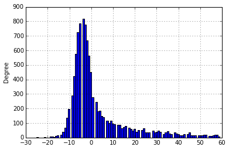

```python
delays = pd.read_sql_query(qDelays, engine)['DepDelay'].dropna()
delays.plot(kind='hist', bins=100)
```

## Average Delay Grouped By Day of Week- Seems to be differences

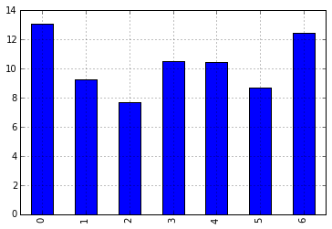

```python
pd.read_sql_query(daysAvg, engine)['AVG(DepDelay)'].plot(kind='bar')
```

## Is there a real difference between the samples? Kruskal-Wallis Test (non-parametric ANOVA)

### Results of test suggest that there is a difference. The p-value is close to 0, the null hypothesis is therefore rejected. H-statistic is also high which means that there is greater variance between groups than within

```python
f, p = stats.mstats.kruskalwallis(days[0],days[1],days[2],days[3],days[4],days[5],days[6])
print('f_stat: '+str(f), 'p_val: '+str(p))
```

```
f_stat: 5576.3932233 p_val: 0.0
```

## Truly Cumbersome Delays are over 60 minutes

### Here I isolate delays over 60 minutes. Does the day of the week still matter?

```python
delaysGT60 = pd.read_sql_query(delayGT60, engine).merge(pd.read_sql_query(countFlights, engine))
delaysGT60['%Delayed'] = delaysGT60['COUNT(DepDelay)']/delaysGT60['COUNT(*)']*100
delaysGT60
```

|  | DayOfWeek | COUNT(DepDelay) | AVG(DepDelay) | COUNT(*) | %Delayed |
| --- | --- | --- | --- | --- | --- |
| 0 | 1 | 15106 | 126.282073 | 212780 | 7.099351 |
| 1 | 2 | 11638 | 120.293693 | 204943 | 5.678652 |
| 2 | 3 | 8791 | 119.220566 | 191840 | 4.582465 |
| 3 | 4 | 12311 | 122.198359 | 210703 | 5.842821 |
| 4 | 5 | 12245 | 120.547979 | 214073 | 5.720011 |
| 5 | 6 | 8390 | 126.488796 | 172059 | 4.876234 |
| 6 | 7 | 13601 | 126.162267 | 197073 | 6.901504 |

### Results of below test suggest that there is a difference. The p-value is close to 0, the null hypothesis is therefore rejected. H-statistic is also high which means that there is greater variance between groups than within

```python
h, p = stats.mstats.kruskalwallis(days3[0],days3[1],days3[2],days3[3],days3[4],days3[5],days3[6])
print('h_stat: '+str(f), 'p_val: '+str(p))
```

```
h_stat: 36294.1803275 p_val: 2.19576567896e-19
```

### The Kruskal-Wallis test only tells me that there are differences between the groups, but not which ones

```python
p = []
pVals = []

for i in days3:
    for x in days3:
        a,b = stats.mannwhitneyu(i,x)
        p.append(format(float(b*2), '.6f'))
    pVals.append(p)
    p =[]

pd.DataFrame(pVals, columns=range(1,8), index=range(1,8))
```

|  | 1 | 2 | 3 | 4 | 5 | 6 | 7 |
| --- | --- | --- | --- | --- | --- | --- | --- |
| 1 | 0.999999 | 0.000025 | 0.000000 | 0.000228 | 0.000000 | 0.000898 | 0.737940 |
| 2 | 0.000025 | 0.999999 | 0.000006 | 0.615815 | 0.223672 | 0.738498 | 0.000144 |
| 3 | 0.000000 | 0.000006 | 0.999999 | 0.000001 | 0.000703 | 0.000013 | 0.000000 |
| 4 | 0.000228 | 0.615815 | 0.000001 | 0.999999 | 0.093060 | 0.953666 | 0.000954 |
| 5 | 0.000000 | 0.223672 | 0.000703 | 0.093060 | 0.999999 | 0.159695 | 0.000000 |
| 6 | 0.000898 | 0.738498 | 0.000013 | 0.953666 | 0.159695 | 0.999999 | 0.002555 |
| 7 | 0.737940 | 0.000144 | 0.000000 | 0.000954 | 0.000000 | 0.002555 | 0.999999 |

## Percent of Cancelled Flights Grouped By Day of Week. Does day of week affect cancellations too?

```python
cancelled = pd.read_sql_query(qCan, engine).merge(pd.read_sql_query(countFlights, engine))
cancelled['%Cancelled'] = cancelled['SUM(cancelled)']/cancelled['COUNT(*)']*100
cancelled
```

|  | DayOfWeek | SUM(cancelled) | COUNT(*) | %Cancelled |
| --- | --- | --- | --- | --- |
| 0 | 1 | 10649 | 212780 | 5.004700 |
| 1 | 2 | 7421 | 204943 | 3.621007 |
| 2 | 3 | 4558 | 191840 | 2.375938 |
| 3 | 4 | 5952 | 210703 | 2.824829 |
| 4 | 5 | 3559 | 214073 | 1.662517 |
| 5 | 6 | 3831 | 172059 | 2.226562 |
| 6 | 7 | 7531 | 197073 | 3.821427 |

## Is there a real difference between the samples? Kruskal-Wallis Test (non-parametric ANOVA)

### Results of test suggest that there is a difference. The p-value is close to 0, the null hypothesis is therefore rejected. H-statistic is also high which means that there is greater variance between groups than within

```python
h, p = stats.mstats.kruskalwallis(days2[0],days2[1],days2[2],days2[3],days2[4],days2[5],days2[6])
print('h_stat: '+str(f), 'p_val: '+str(p))
```

```
h_stat: 36294.1803275 p_val: 0.0
```

### Here I again compare each day to each other. Tests suggest that some days may be the same

```python
p = []
pVals = []

for i in days2:
    for x in days2:
        a,b = stats.mannwhitneyu(i,x)
        p.append(format(float(b*2), '.6f'))
    pVals.append(p)
    p =[]

pd.DataFrame(pVals, columns=range(1,8), index=range(1,8))
```

|  | 1 | 2 | 3 | 4 | 5 | 6 | 7 |
| --- | --- | --- | --- | --- | --- | --- | --- |
| 1 | 1.000000 | 0.000000 | 0.000000 | 0.000000 | 0.000000 | 0.000000 | 0.000000 |
| 2 | 0.000000 | 1.000000 | 0.000000 | 0.000009 | 0.000000 | 0.000000 | 0.271204 |
| 3 | 0.000000 | 0.000000 | 1.000000 | 0.013749 | 0.000085 | 0.435850 | 0.000000 |
| 4 | 0.000000 | 0.000009 | 0.013749 | 1.000000 | 0.000000 | 0.001427 | 0.000000 |
| 5 | 0.000000 | 0.000000 | 0.000085 | 0.000000 | 1.000000 | 0.002550 | 0.000000 |
| 6 | 0.000000 | 0.000000 | 0.435850 | 0.001427 | 0.002550 | 1.000000 | 0.000000 |
| 7 | 0.000000 | 0.271204 | 0.000000 | 0.000000 | 0.000000 | 0.000000 | 1.000000 |

## Do carriers affect delay times?

```python
carriers = pd.read_sql_query(carrDelays, engine).merge(pd.read_sql_query(carrGT60, engine))
carriers = carriers.merge(pd.read_sql_query(countFlightsCarr, engine))
carriers['% > 60'] = carriers['COUNT(DepDelay)']/carriers['COUNT(*)']*100
carriers = carriers.sort(columns='COUNT(*)', ascending=False).head(7)
carriers.index = carriers['UniqueCarrier']
del carriers['UniqueCarrier']
```

```python
carriers
```

| UniqueCarrier | AVG(DepDelay) | COUNT(DepDelay) | COUNT(*) | % > 60 |
| --- | --- | --- | --- | --- |
| WN | 9.843637 | 13897 | 299459 | 4.640702 |
| DL | 8.759464 | 8942 | 199471 | 4.482857 |
| EV | 9.875440 | 9808 | 149253 | 6.571392 |
| OO | 9.540316 | 9576 | 142181 | 6.735077 |
| AA | 10.669361 | 7363 | 129860 | 5.669952 |
| UA | 14.265419 | 8224 | 118233 | 6.955757 |
| US | 6.650787 | 4268 | 98158 | 4.348092 |

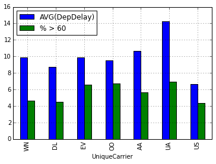

```python
carriers[['AVG(DepDelay)', '% > 60']].plot(kind='bar')
```

## Is there a real difference between the samples? Kruskal-Wallis Test (non-parametric ANOVA)

### Results of test suggest that there is a difference. The p-value is close to 0, the null hypothesis is therefore rejected. H-statistic is also high which means that there is greater variance between groups than within

```python
h, p = stats.mstats.kruskalwallis(carrs[0],carrs[1],carrs[2],carrs[3],carrs[4],carrs[5],carrs[6])
print('h_stat: '+str(f), 'p_val: '+str(p))
```

```
h_stat: 36294.1803275 p_val: 0.0
```

### Here I again compare each day to each other. Tests suggest that all carriers are different

```python
p = []
pVals = []

for i in carrs:
    for x in carrs:
        a,b = stats.mannwhitneyu(i,x)
        p.append(format(float(b*2), '.6f'))
    pVals.append(p)
    p =[]

pd.DataFrame(pVals, columns=range(1,8), index=range(1,8))
```

|  | 1 | 2 | 3 | 4 | 5 | 6 | 7 |
| --- | --- | --- | --- | --- | --- | --- | --- |
| 1 | 1.000000 | 0.000000 | 0.000000 | 0.000000 | 0.000000 | 0.000000 | 0.000000 |
| 2 | 0.000000 | 1.000000 | 0.000000 | 0.000000 | 0.000000 | 0.000000 | 0.000000 |
| 3 | 0.000000 | 0.000000 | 1.000000 | 0.000000 | 0.000000 | 0.000000 | 0.000000 |
| 4 | 0.000000 | 0.000000 | 0.000000 | 1.000000 | 0.000000 | 0.000000 | 0.000000 |
| 5 | 0.000000 | 0.000000 | 0.000000 | 0.000000 | 1.000000 | 0.000000 | 0.000000 |
| 6 | 0.000000 | 0.000000 | 0.000000 | 0.000000 | 0.000000 | 1.000000 | 0.000000 |
| 7 | 0.000000 | 0.000000 | 0.000000 | 0.000000 | 0.000000 | 0.000000 | 1.000000 |

## Conclusion

The tests suggest that the day of week and the carriers do affect the delay times for flights. Using this simple data analysis I will move on to try to forecast the flights delayed at a specific airport.